# LCL data : cell ordering

Kushal K Dey

November 6, 2015

```r
library(qtlcharts)
library(CountClust)
library(parallel)
library(cellcycleR)
library(data.table)
library(binhf)
library(vioplot)
library(limma)
library(readxl)
library(readr)
library(mygene)
library(knitr)
```

## Objective

In this script, we perform the cellcycleR method on the LCLs, which are not stem cells and may behave similar to the normal cells and show the growth phases, which we did not see in the stem cell studies we observed so far.

## Data Preparation

We first prepare the LCL single cell data.

```r
setwd('/Users/kushal/Documents/singleCell-method/project/analysis')
lcl_qc_data <- read_csv("../data/qc-lcl.csv");
lcl_annotations <- read.table('../data/annotation-lcl.txt',header=TRUE);
lcl_molecules <- t(data.frame(fread('../data/molecules-lcl.txt'), row.names = 1));

lcl_indices <- match(lcl_qc_data$ll_name, lcl_annotations$well)

lcl_molecules_refined <- lcl_molecules[lcl_indices,];
lcl_annotations_refined <- lcl_annotations[lcl_indices,];

well_id <- lcl_annotations_refined$well;
ids <- sapply(well_id, function(x) substring(x,2,3))
batch_lab <- array(0, length(ids))
batch_lab[which(ids=="01" | ids=="02" | ids=="03")]=1;
batch_lab[which(ids=="04" | ids=="05" | ids=="06")]=2;
batch_lab[which(ids=="07" | ids=="08" | ids=="09")]=3;
batch_lab[which(ids=="10" | ids=="11" | ids=="12")]=4;


lcl_single_cells <- lcl_molecules_refined[which(lcl_qc_data$cell.num==1),];
batch_lab_single_cells <- batch_lab[which(lcl_qc_data$cell.num==1)];
```

Now we focus only on the cell cycle genes listed in Macosko paper.

```r
reads_lcl <- data.frame(fread('../data/reads-lcl.txt'),row.names=TRUE);
reads_lcl <- reads_lcl[,lcl_indices];
reads_lcl_single <- reads_lcl[,which(lcl_qc_data$cell.num==1)];
reads_single <- as.matrix(reads_lcl_single)

cell_cycle_genes <- read.table("../data/cellcyclegenes.txt", header = TRUE, sep="\t")

## create 5 lists of 5 phases (de-level and then remove "")
cell_cycle_genes_list <- lapply(1:5,function(x){
  temp <- as.character(cell_cycle_genes[,x])
  temp[temp!=""]
})

labs=unique(unlist(lapply(1:5, function(k) match(cell_cycle_genes_list[[k]],colnames(lcl_single_cells)))));
labs = labs[!is.na(labs)];
lcl_single_cell_cycle_genes <- lcl_single_cells[,labs];

batch_corrected_cell_cycle_genes <- BatchCorrectedCounts(lcl_single_cell_cycle_genes,batch_lab_single_cells,use_parallel=TRUE)

cycle_counts_data <-batch_corrected_cell_cycle_genes

dim(cycle_counts_data)
```

[output not shown]

We now mean center and stanadardize the data for applying cellcycleR.

```r
cycle_voom_data <- voom(cycle_counts_data)$E;
cycle_data_norm <- apply(cycle_voom_data,2,function(x)  return (x-mean(x))/sd(x))
celltime_levels <- 100;
cycle_data_norm <- cycle_data_norm[, -which(colSums(cycle_data_norm)==0)]

dim(cycle_data_norm)
```

[output not shown]

## Applying cellcycleR on LCL data

```r
out <- cell_ordering_class(cycle_data_norm, celltime_levels = 100, num_iter=100, save_path="../rdas/cell_order_lcl.rda")
```

We ran the method above once already (took around 2 minutes) and now we just load the output.

```r
out <- get(load(file="../rdas/cell_order_lcl.rda"));
cell_order_full <- cell_ordering_full(out$signal_intensity, dim(cycle_data_norm)[2])
```

We look at the plots of the amplitudes, phases and the non signal variation of the genes.

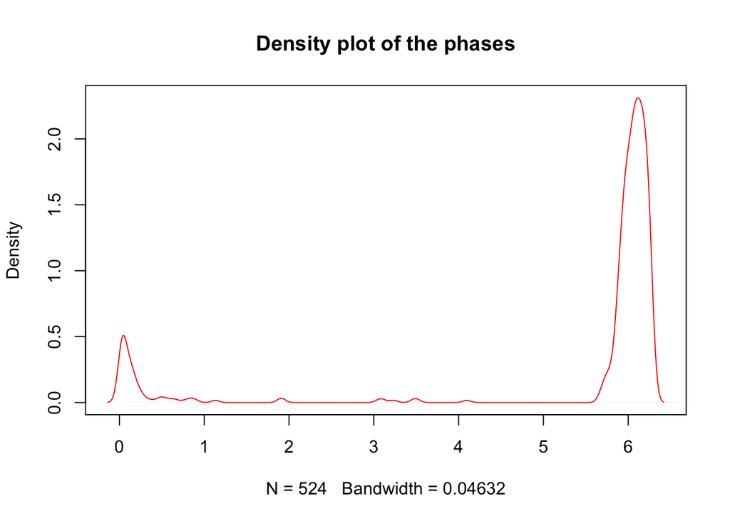

```r
amp_genes <- out$amp;
sd_genes <- out$sigma;
phi_genes <- out$phi;

plot(density(phi_genes), col="red", main="Density plot of the phases")
```

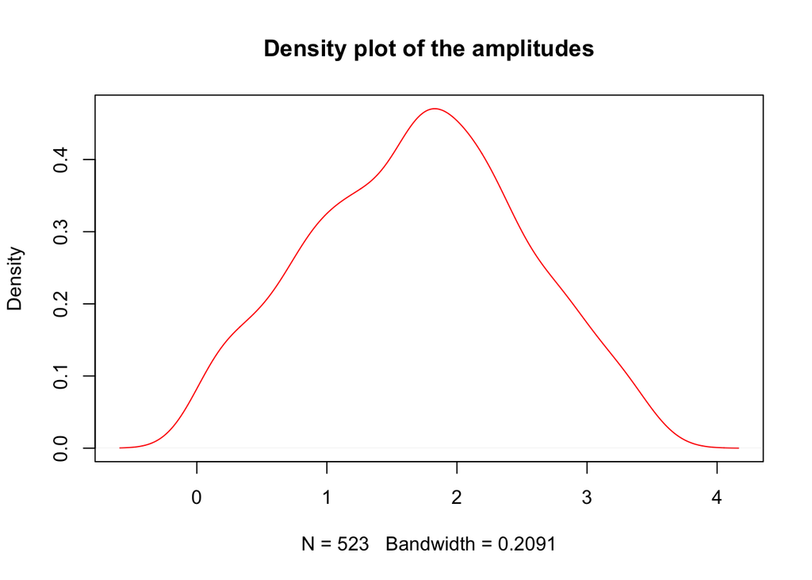

```r
plot(density(amp_genes[-which.max(amp_genes)]), col="red", main="Density plot of the amplitudes")
```

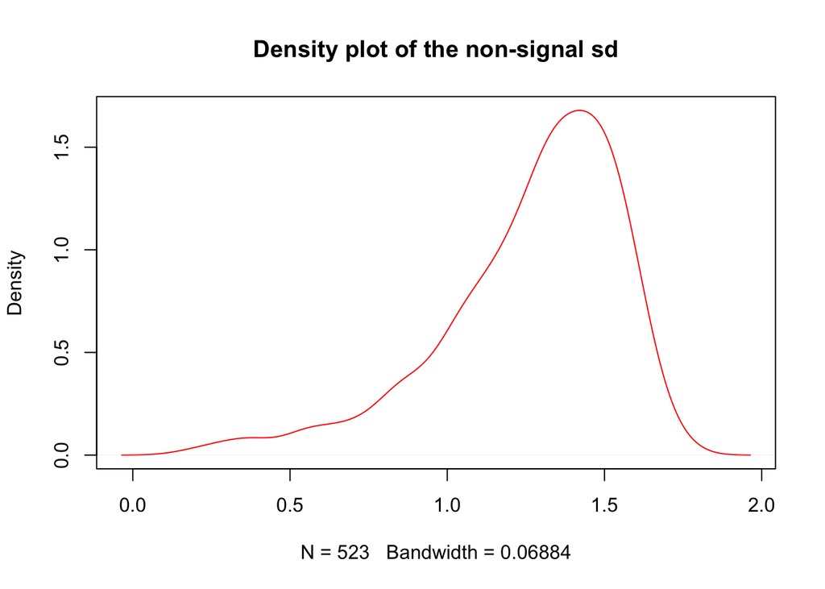

```r
plot(density(sd_genes[-which.max(sd_genes)]), col="red", main="Density plot of the non-signal sd")
```

We extract the genes with high SNR - these are more likely to be sinusoidal.

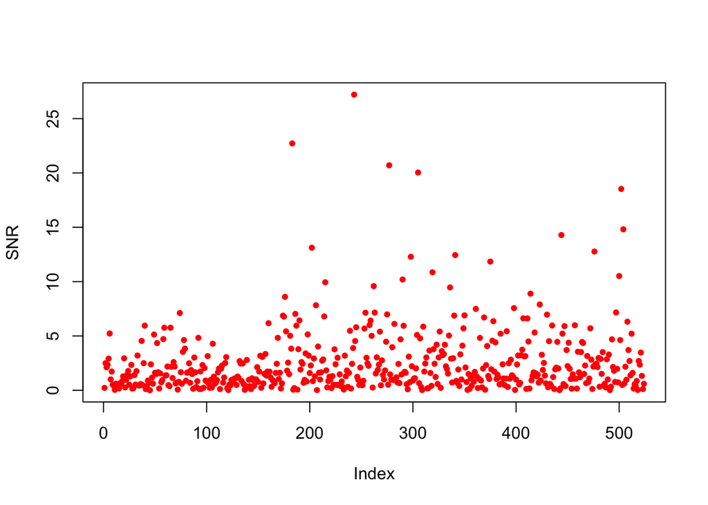

```r
ESS <- amp_genes^2; RSS <- sd_genes^2

SNR <- ESS/RSS;

plot(SNR, col="red", pch=20, lwd=1)
```

```r
top_genes <- which(SNR > 3);
```

Next we plot the qtlcharts for these top sinusoidal genes and see if their patterns are indeed sinusoidal or not.

```r
iplotCurves(t(cycle_data_norm[order(cell_order_full),top_genes]))
```

```
## Set screen size to height=700 x width=1000
```

[interactive chart not shown]

## Redoing on high SNR genes

We extract the high SNR genes as they seem to have sinusoidal patterns and repeat the procedure again. The aim here is to see how much robust the analysis is to the selction of the (most) sinusoidal genes.

```r
snr_high_indices <- which(SNR > 1);

cycle_data_norm_sinusoidal <- cycle_data_norm[,snr_high_indices];

dim(cycle_data_norm_sinusoidal)
```

```
## [1]  84 333
```

We apply the cell ordering mechanism (it takes around 5 minutes to run)

```r
out2 <- cell_ordering_class(cycle_data_norm_sinusoidal, celltime_levels = 100, num_iter=100,
                            save_path="../rdas/cell_order_lcl_sinusoidal.rda")
```

We reload the output

```r
out2 <- get(load(file="../rdas/cell_order_lcl_sinusoidal.rda"));
cell_order_full <- cell_ordering_full(out2$signal_intensity, dim(cycle_data_norm_sinusoidal)[2])
```

We plot the same features as above and check for the robustness. We needed to shift the cell order so as to compare with previous plot on all genes as the method is non-identifiable upto a rotation.

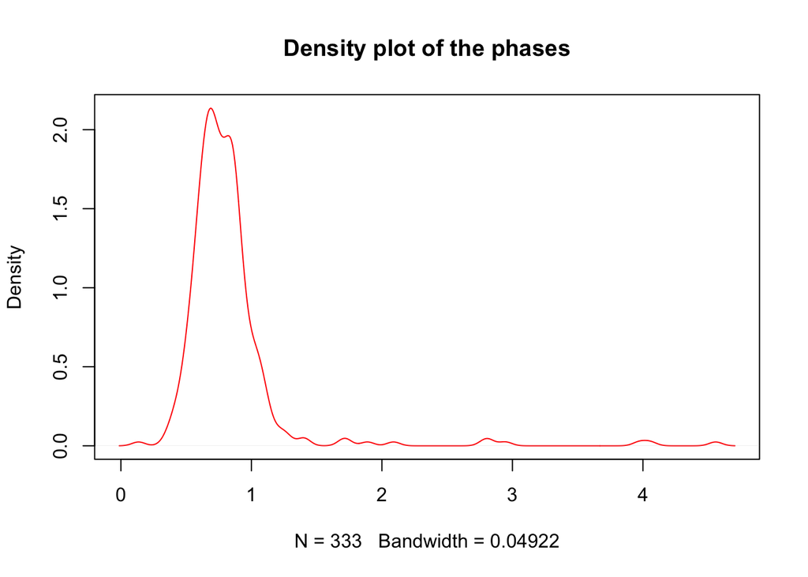

```r
amp_genes <- out2$amp;
sd_genes <- out2$sigma;
phi_genes <- out2$phi;

plot(density(phi_genes), col="red", main="Density plot of the phases")
```

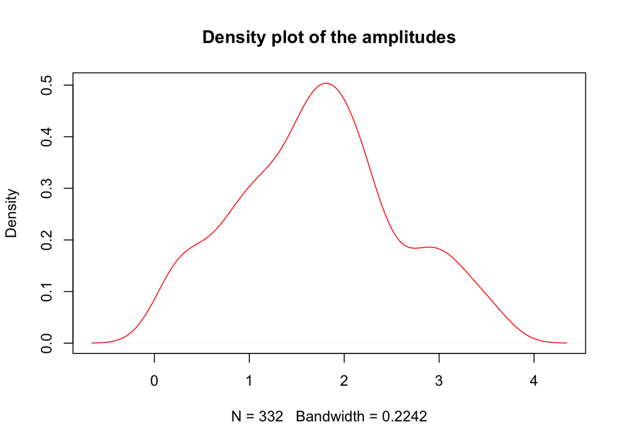

```r
plot(density(amp_genes[-which.max(amp_genes)]), col="red", main="Density plot of the amplitudes")
```

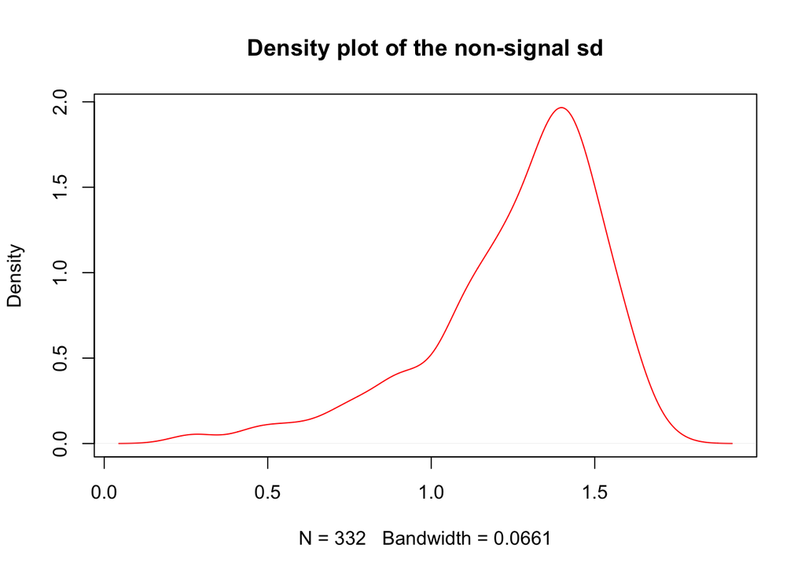

```r
plot(density(sd_genes[-which.max(sd_genes)]), col="red", main="Density plot of the non-signal sd")
```

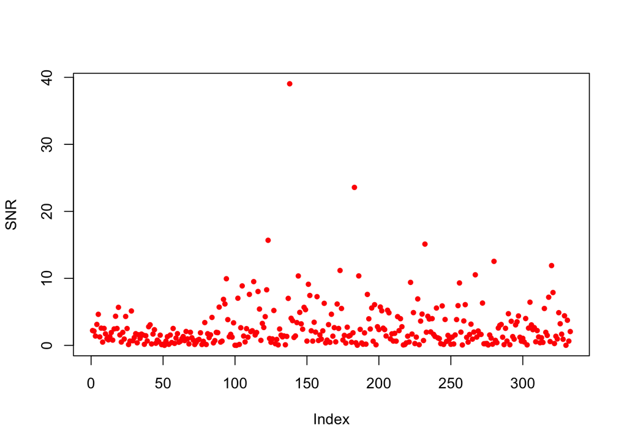

```r
ESS <- amp_genes^2; RSS <- sd_genes^2

SNR <- ESS/RSS;

plot(SNR, col="red", pch=20, lwd=1)
```

```r
top_genes <- which(SNR > 3);
#new_cell_order <- shift(order(cell_order_full),1)
iplotCurves(t(cycle_data_norm_sinusoidal[order(cell_order_full),top_genes]))
```

[interactive chart not shown]

## Observations

The LCL genes do not look as sinusoidal as the iPSC data looked. The sinusoidal assumption overall is not visible for many of the genes, despite them showing high SNR. We perform gene annotations to see if the method picks up genes that are meaningful and are related to cell cycle or not.

```r
sinusoidal_gene_names <- colnames(cycle_data_norm_sinusoidal);
imp_genes <- sinusoidal_gene_names[order(SNR, decreasing=TRUE)]
top_genes_100 <- imp_genes[1:100];
out <- queryMany(top_genes_100,  scopes="ensembl.gene", fields=c("name","summary"), species="human");
```

```
## Finished
## Pass returnall=TRUE to return lists of duplicate or missing query terms.
```

```r
kable(as.data.frame(out))
```

| name | query | summary | X_id | notfound |
| --- | --- | --- | --- | --- |
| histidine triad nucleotide binding protein 3 | ENSG00000111911 | Histidine triad proteins, such as HINT3, are nucleotide hydrolases and transferases that act on the alpha-phosphate of ribonucleotides (Brenner, 2002 [PubMed 12119013]). | 135114 | NA |
| transcription termination factor, RNA polymerase II | ENSG00000116830 | This gene encodes a member of the SWI2/SNF2 family of proteins, which play a critical role in altering protein-DNA interactions. The encoded protein has been shown to have dsDNA-dependent ATPase activ… | 8458 | NA |
| cell division cycle associated 3 | ENSG00000111665 | NA | 83461 | NA |
| Kruppel-like factor 9 | ENSG00000119138 | The protein encoded by this gene is a transcription factor that binds to GC box elements located in the promoter. Binding of the encoded protein to a single GC box inhibits mRNA expression while bindi… | 687 | NA |
| 1-acylglycerol-3-phosphate O-acyltransferase 3 | ENSG00000160216 | The protein encoded by this gene is an acyltransferase that converts lysophosphatidic acid into phosphatidic acid, which is the second step in the de novo phospholipid biosynthetic pathway. The encode… | 56894 | NA |
| protein phosphatase 6, regulatory subunit 3 | ENSG00000110075 | Protein phosphatase regulatory subunits, such as SAPS3, modulate the activity of protein phosphatase catalytic subunits by restricting substrate specificity, recruiting substrates, and determining the… | 55291 | NA |
| Sin3A-associated protein, 30kDa | ENSG00000164105 | Histone acetylation plays a key role in the regulation of eukaryotic gene expression. Histone acetylation and deacetylation are catalyzed by multisubunit complexes. The protein encoded by this gene is… | 8819 | NA |
| transportin 1 | ENSG00000083312 | This gene encodes the beta subunit of the karyopherin receptor complex which interacts with nuclear localization signals to target nuclear proteins to the nucleus. The karyopherin receptor complex is … | 3842 | NA |
| tubulin, delta 1 | ENSG00000108423 | NA | 51174 | NA |
| KIAA1524 | ENSG00000163507 | NA | 57650 | NA |
| ribonucleotide reductase M1 | ENSG00000167325 | This gene encodes one of two non-identical subunits that constitute ribonucleoside-diphosphate reductase, an enzyme essential for the production of deoxyribonucleotides prior to DNA synthesis in S pha… | 6240 | NA |
| bromodomain containing 8 | ENSG00000112983 | The protein encoded by this gene interacts with thyroid hormone receptor in a ligand-dependent manner and enhances thyroid hormone-dependent activation from thyroid response elements. This protein con… | 10902 | NA |
| G protein-coupled receptor kinase 6 | ENSG00000198055 | This gene encodes a member of the guanine nucleotide-binding protein (G protein)-coupled receptor kinase subfamily of the Ser/Thr protein kinase family. The protein phosphorylates the activated forms … | 2870 | NA |
| SET domain containing (lysine methyltransferase) 8 | ENSG00000183955 | NA | 387893 | NA |
| lamin B receptor | ENSG00000143815 | The protein encoded by this gene belongs to the ERG4/ERG24 family. It localized in the nuclear envelope inner membrane and anchors the lamina and the heterochromatin to the membrane. It may mediate in… | 3930 | NA |
| ubiquitin specific peptidase 1 | ENSG00000162607 | This gene encodes a member of the ubiquitin-specific processing (UBP) family of proteases that is a deubiquitinating enzyme (DUB) with His and Cys domains. This protein is located in the cytoplasm and… | 7398 | NA |
| cell division cycle associated 2 | ENSG00000184661 | NA | 157313 | NA |
| caspase 3, apoptosis-related cysteine peptidase | ENSG00000164305 | This gene encodes a protein which is a member of the cysteine-aspartic acid protease (caspase) family. Sequential activation of caspases plays a central role in the execution-phase of cell apoptosis. … | 836 | NA |
| protein regulator of cytokinesis 1 | ENSG00000198901 | This gene encodes a protein that is involved in cytokinesis. The protein is present at high levels during the S and G2/M phases of mitosis but its levels drop dramatically when the cell exits mitosis … | 9055 | NA |
| atlastin GTPase 2 | ENSG00000119787 | NA | 64225 | NA |
| ankyrin repeat domain 40 | ENSG00000154945 | NA | 91369 | NA |
| NA | ENSG00000152022 | NA | NA | TRUE |
| meiotic nuclear divisions 1 | ENSG00000121211 | The product of the MND1 gene associates with HOP2 (MIM 608665) to form a stable heterodimeric complex that binds DNA and stimulates the recombinase activity of RAD51 (MIM 179617) and DMC1 (MIM 602721)… | 84057 | NA |
| perilipin 3 | ENSG00000105355 | Mannose 6-phophate receptors (MPRs) deliver lysosomal hydrolase from the Golgi to endosomes and then return to the Golgi complex. The protein encoded by this gene interacts with the cytoplasmic domain… | 10226 | NA |
| thymidylate synthetase | ENSG00000176890 | Thymidylate synthase catalyzes the methylation of deoxyuridylate to deoxythymidylate using 5,10-methylenetetrahydrofolate (methylene-THF) as a cofactor. This function maintains the dTMP (thymidine-5-p… | 7298 | NA |
| HAUS augmin-like complex, subunit 8 | ENSG00000131351 | HAUS8 is 1 of 8 subunits of the 390-kD human augmin complex, or HAUS complex. The augmin complex was first identified in Drosophila, and its name comes from the Latin verb ‘augmentare,’ meaning ‘to in… | 93323 | NA |
| heat shock protein 70kDa family, member 13 | ENSG00000155304 | The protein encoded by this gene is a member of the heat shock protein 70 family and is found associated with microsomes. Members of this protein family play a role in the processing of cytosolic and … | 6782 | NA |
| RecQ mediated genome instability 1 | ENSG00000178966 | RMI1 is a component of protein complexes that limit DNA crossover formation via the dissolution of double Holliday junctions (Raynard et al., 2006 [PubMed 16595695]). | 80010 | NA |
| interleukin enhancer binding factor 2 | ENSG00000143621 | The protein encoded by this gene is a transcription factor required for T-cell expression of the interleukin 2 gene. It also binds RNA and is an essential component for encapsidation and protein primi… | 3608 | NA |
| thioredoxin domain containing 9 | ENSG00000115514 | The protein encoded by this gene is a member of the thioredoxin family. The exact function of this protein is not known but it is associated with cell differentiation. | 10190 | NA |

[output cut: 70 more lines]